# Exploratory Analyses for Missing Data in Meta-Analyses - Vignette

May 2020

## Introduction

This vignette is part of the supplementary material to the “Exploratory Analyses for Missing Data in Meta-Analyses” tutorial. We investigate exploratory analysis methods for diagnosing missing data problems in a meta-analysis, including data visualizations and numerical summaries. Here, we expand results published in our tutorial and detail executable code.

Using the tools developed in `naniar` and `visdat` packages in `R` (Tierney, 2017; Tierney & Cook, 2018) and some custom extensions, developed specifically for meta-analysis, we aim to work with the four following topics:

1. Aggregation Plots
2. Univariate Explorations
3. Exploring Patterns of Missingness
4. Numerical summaries for missing data

##Load data and packages

We start by loading the necessary packages and data frame.

```r
library(naniar)
library(ggplot2)
library(visdat)
library(tidyverse)
library(gridExtra)
library(grid)
library(cowplot)
adt_data <- readRDS("../data/adt_data.RDS")
```

##Clean data

Later, we select relevant variables to the analysis. We include Effect Size estimates, corresponding Standard Errors and 22 covariates related to the intervention.

```r
data <- adt_data %>%
   select(
      `EffectSize` = es_g,
      `StandardError`= se_g,
      `Timing_of_FollowUp`= estimingpost,
      `Design`= design,
      `Group1_TreatmentCategory`= g1txcat,
      `Group1_TreatmentLocation`=g1loc,
      `Group1_HrsPerWeek`= g1hrsperweek,
      `Group1_TreatmentDays`= g1txdays,
      `Group1_NumSession`= g1numsessions,
      `Group1_MeanAge`=g1age,
      `Group1_PctWhite`= g1perwhite,
      `Group1_PctBlack`=g1perblack,
      `Group1_PctHisp`=g1perhisp,
      `Group1_PctMale`=g1permale,
      `Group2_TreatmentCategory`=g2txcat,
      `Group2_TreatmentLocation`=g2loc,
      `Group2_HrsPerWeek`= g2hrsperweek,
      `Group2_TreatmentDays`= g2txdays,
      `Group2_NumSession`=g2numsessions,
      `Group2_MeanAge`=g2age,
      `Group2_PctWhite`=g2perwhite,
      `Group2_PctBlack`=g2perblack,
      `Group2_PctHisp`=g2perhisp,
      `Group2_PctMale`=g2permale)
```

## Aggregation Plots

Aggregation plots can be a useful starting point when exploring missingness in a meta-analytic dataset. They visualize the entire dataset as a “heatmap” that indicates which values are missing from which rows. Two examples are presented using the `visdat` package and the wrapper function `gg_summary_covariate_miss`.

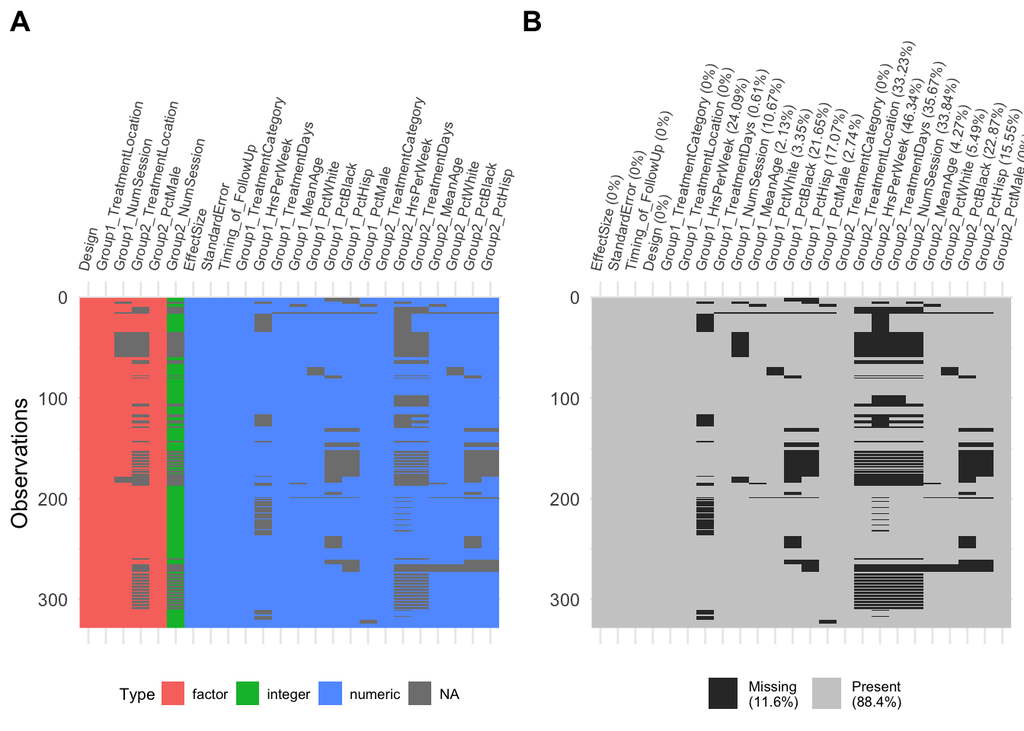

```r
#summary plots using vis_dat, vis_miss and gg_summary_covariate_miss wrapper function
source("../code/wrappers.R")
gg_summary_covariate_miss(data)
```

## Univariate Explorations

Univariate plots provide detailed information about how many observations are missing a given variable. Using the `gg_miss_var` function from the `naniar` package, we present two approaches to making these plots.

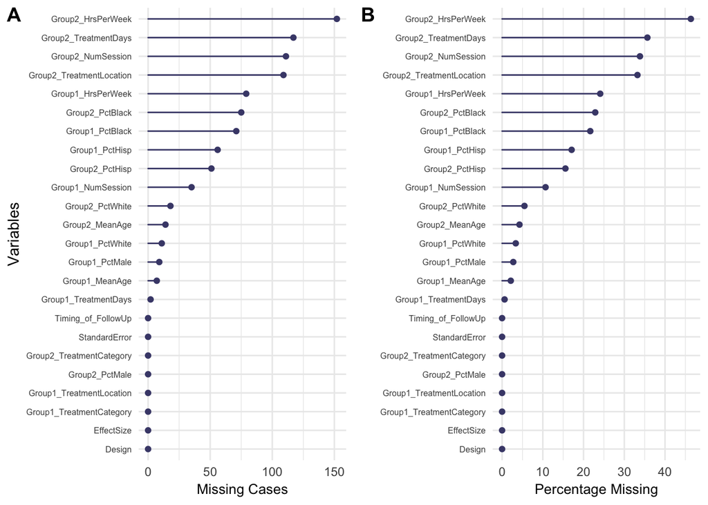

```r
#Summary of missing variables
p1<- gg_miss_var(data) +
                            labs(y="Missing Cases")+
                            theme(axis.title.x = element_text(size =10),
                                  axis.text.y = element_text(size=6))


#Summary of missing variables (percentage)
p2<- gg_miss_var(data, show_pct=TRUE)+
                                          labs(y="Percentage Missing")+
                                          theme(axis.title.x = element_text(size =10),
                                                axis.text.y = element_text(size=6))

plot_grid(p1, p2 +
                    labs(x=""),
                    ncol = 2,
                    labels=c('A','B')
             )
```

We can identify variables that present a greater number or percentage of missing cases. For example, plot B suggests that the hours per week that the contrast group spent in their assigned condition (Group2_HrsPerWeek) is missing for almost half of the effects in the data.

We can also look at the number of missing values in each case (effect size) by using the `gg_miss_case` function.

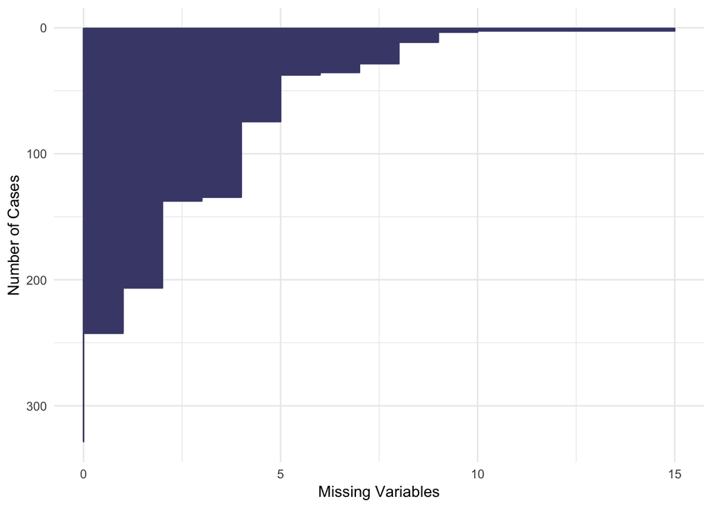

```r
#Missingness in cases. Number of missing values in each case
gg_miss_case(data, order_cases=TRUE) +
                                            labs(x="Number of Cases")+
                                            labs(y="Missing Variables")
```

## Exploring Patterns of Missingness

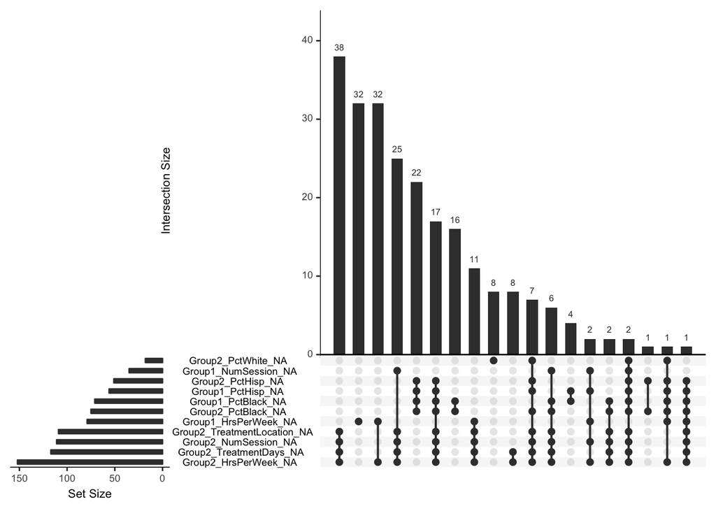

```r
gg_miss_upset(data, nsets=11, nintersects=NA)
```

This plot shows different missingness patterns for our data. Particularly, the first missingness pattern corresponds to rows (effect sizes) where hours per week (Group2_HrsPerWeek_NA), number of days (Group2_TreatmentDays_NA), number of sessions (Group2_NumSession_NA), and location (Group2_TreatmentLocation_NA) of group 2 in this study are all missing. The frequency of occurrence in the data for each pattern is presented in the top part of the plot. For example, this first pattern occurs for 38 effects.

## Relating missingness to observed values

We also examine whether missingness in one variable is related to observed values in another variable. This can highlight potential biases in the observed data and also clarify whether data appear to meet the MCAR assumption.

First, we can use the `gg_miss_fct` function to create a heatmap and understand how different levels of categorical covariates can be related to missingness in other variables. For example, in this plot we explore different types of care provided (columns). For each one of these levels, the cells are shaded according to how frequently those variables are missing.

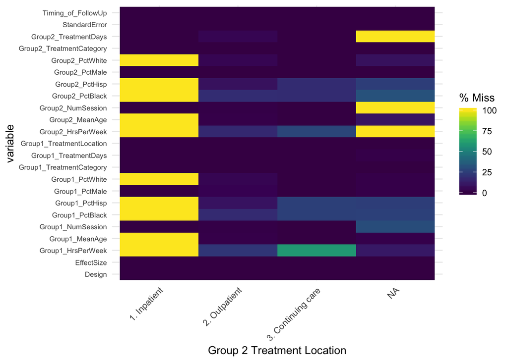

```r
#Group 2 Treatment Location
gg_miss_fct(x=data, fct=`Group2_TreatmentLocation`)  +
                                    labs(x="Group 2 Treatment Location")+
                                    theme(axis.text.y = element_text(size=7))
```

The figure suggests that the percent of subjects who are black or hispanic (Group2_PctBlack and Group2_PctHisp) are much more frequently missing from effects with inpatient treatments than outpatient or continuing care interventions.

A second approach is to plot the level of missingness over the levels of care provided using the `gg_miss_case` function. For each level of this categorical variable, the plot displays the number of missing cases in each effect size.

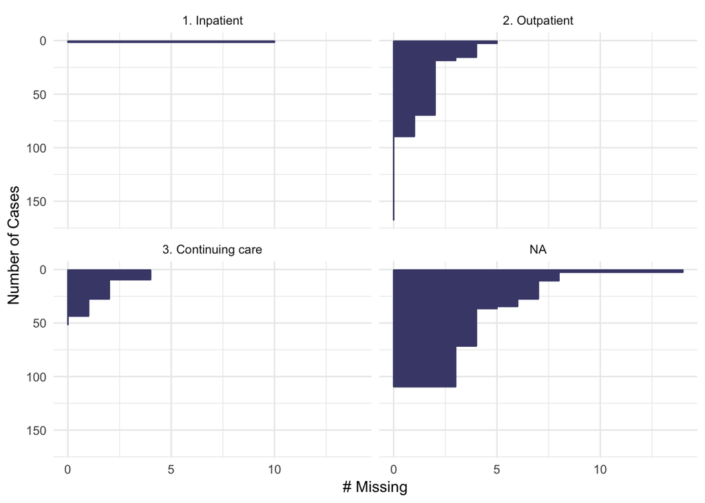

```r
#Group 2 Treatment Location
gg_miss_case(x=data, facet=`Group2_TreatmentLocation`) + labs(x="Number of Cases")
```

Third, effect size estimates and their estimation error variances (or standard errors $\sigma_i$) are two relevant variables in most meta-analysis. Density plots are appropriate since we are working with two continuous variables. To facilitate this visualization, we can use the `shadow` function to keep track of missing values and then create a data frame with the same set of columns, but with the column names added a suffix_NA.

```r
#create shadow dataframe
as_shadow(data)
```

```
## # A tibble: 328 x 24
##    EffectSize_NA StandardError_NA Timing_of_Follo… Design_NA
##    <fct>         <fct>            <fct>            <fct>
##  1 !NA           !NA              !NA              !NA
##  2 !NA           !NA              !NA              !NA
##  3 !NA           !NA              !NA              !NA
##  4 !NA           !NA              !NA              !NA
##  5 !NA           !NA              !NA              !NA
##  6 !NA           !NA              !NA              !NA
##  7 !NA           !NA              !NA              !NA
##  8 !NA           !NA              !NA              !NA
##  9 !NA           !NA              !NA              !NA
## 10 !NA           !NA              !NA              !NA
## # … with 318 more rows, and 20 more variables:
## #   Group1_TreatmentCategory_NA <fct>, Group1_TreatmentLocation_NA <fct>,
## #   Group1_HrsPerWeek_NA <fct>, Group1_TreatmentDays_NA <fct>,
## #   Group1_NumSession_NA <fct>, Group1_MeanAge_NA <fct>,
## #   Group1_PctWhite_NA <fct>, Group1_PctBlack_NA <fct>,
## #   Group1_PctHisp_NA <fct>, Group1_PctMale_NA <fct>,
## #   Group2_TreatmentCategory_NA <fct>, Group2_TreatmentLocation_NA <fct>,
## #   Group2_HrsPerWeek_NA <fct>, Group2_TreatmentDays_NA <fct>,
## #   Group2_NumSession_NA <fct>, Group2_MeanAge_NA <fct>,
## #   Group2_PctWhite_NA <fct>, Group2_PctBlack_NA <fct>,
## #   Group2_PctHisp_NA <fct>, Group2_PctMale_NA <fct>
```

```r
#Attach a shadow to the current dataframe
adt_shadow <- bind_shadow(data)
```

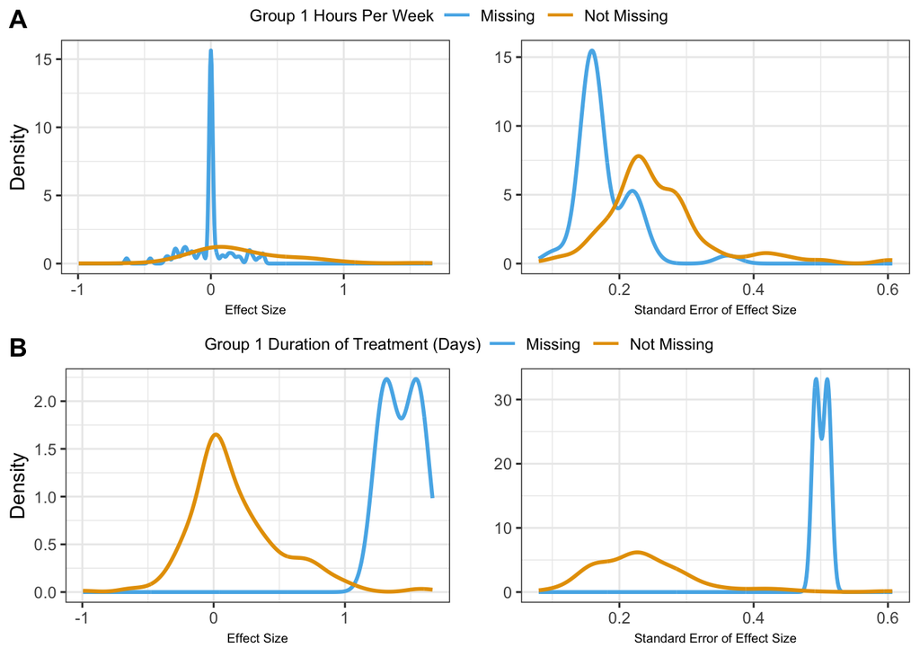

```r
source("../code/wrappers.R")
PlotA<- gg_esse_covariate_miss(adt_shadow,
                       es_col = "EffectSize",
                       se_col = "StandardError",
                       covariate = "Group1_HrsPerWeek",
                       adjust = c(1.3, 1.2), # Adjust smoothing for ES and SE densitites
                       label = "Group 1 Hours Per Week",
                       legend_pos = "top")

PlotB<- gg_esse_covariate_miss(adt_shadow,
                       es_col = "EffectSize",
                       se_col = "StandardError",
                       covariate = "Group1_TreatmentDays",
                       adjust = c(1.3, 1.2), # Adjust smoothing for ES and SE densitites
                       label = "Group 1 Duration of Treatment (Days)",
                       legend_pos = "top")

plot_grid(PlotA, PlotB,
          labels=c('A','B'),
          nrow=2)
```

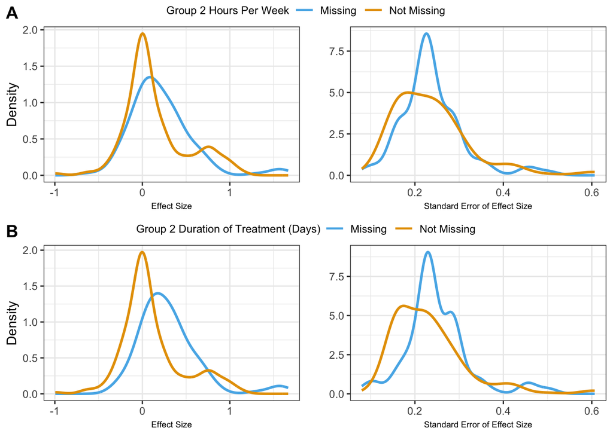

```r
source("../code/wrappers.R")
PlotC<- gg_esse_covariate_miss(adt_shadow,
                       es_col = "EffectSize",
                       se_col = "StandardError",
                       covariate = "Group2_HrsPerWeek",
                       adjust = c(1.3, 1.2), # Adjust smoothing for ES and SE densitites
                       label = "Group 2 Hours Per Week",
                       legend_pos = "top")
PlotD<- gg_esse_covariate_miss(adt_shadow,
                       es_col = "EffectSize",
                       se_col = "StandardError",
                       covariate = "Group2_TreatmentDays",
                       adjust = c(1.3, 1.2), # Adjust smoothing for ES and SE densitites
                       label = "Group 2 Duration of Treatment (Days)",
                       legend_pos = "top")

plot_grid(PlotC, PlotD,
          labels=c('A','B'),
          nrow=2)
```

Plot (C) shows that both, the effect size and its standard errors, have a similar distribution either when the covariate treatment contact (hours per week) for group 2 is present or not.

Forest plots are very common visualizations in meta-analysis. They can also be a useful to examining the relationship between a covariate and effect sizes of the data set. For instance, the following forest plots are shaded by missingness in treatment contact (hours per week) for each one of the treatment groups.

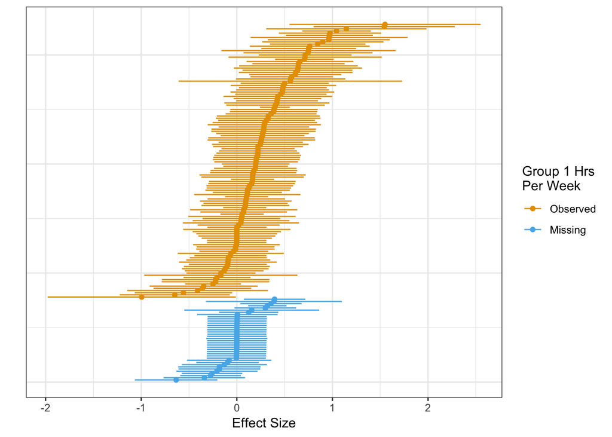

```r
source("../code/wrappers.R")
#Forest plot shaded by missingness in Group 1 Hrs Per Week
PlotE<- gg_forest_covariate_miss(adt_shadow %>% sample_frac(.5),
                         es_col = "EffectSize",
                         se_col = "StandardError",
                         covariate = "Group1_HrsPerWeek",
                         label = "Group 1 Hrs \nPer Week")

PlotE
```

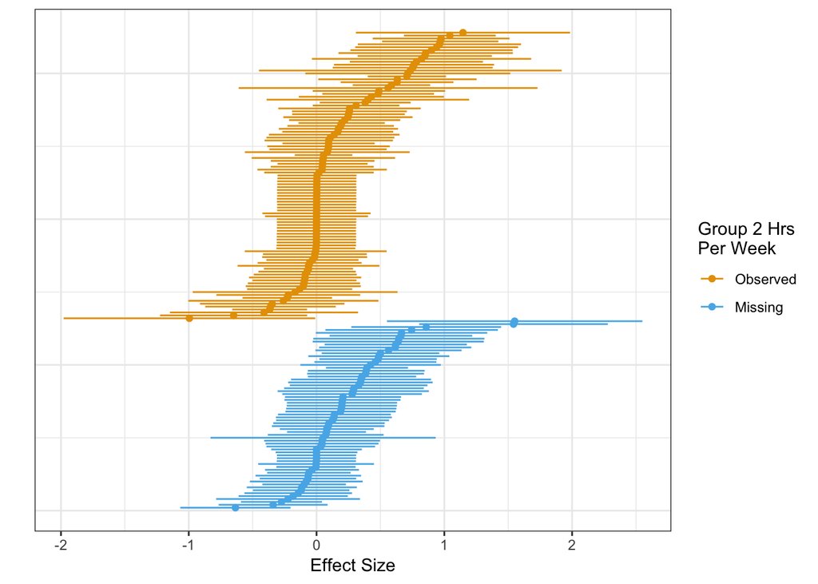

```r
#Forest plot shaded by missingness in Group 2 Hrs Per Week
PlotF<- gg_forest_covariate_miss(adt_shadow %>% sample_frac(.5),
                         es_col = "EffectSize",
                         se_col = "StandardError",
                         covariate = "Group2_HrsPerWeek",
                         label = "Group 2 Hrs \nPer Week")

PlotF
```

## Numerical summaries for missing data

Finally, we explore numerical summaries. We can use different functions under `naniar` to determine raw number, percentages, and proportions of missing observations.

```r
#Total number of missing observations
n_miss(data)
```

```
## [1] 917
```

```r
#Total number of complete observations
n_complete(data)
```

```
## [1] 6955
```

```r
#Proportion missing
prop_miss(data)
```

```
## [1] 0.1164888
```

```r
#Proportion complete
prop_complete(data)
```

```
## [1] 0.8835112
```

```r
#Percentage missing
pct_miss(data)
```

```
## [1] 11.64888
```

```r
#Percentage complete
pct_complete(data)
```

```
## [1] 88.35112
```

```r
#Percentage missing at least one covariate
miss_percentage<- table(rowSums(is.na(data[,3:24])))
1- (miss_percentage[1]/length(data$StandardError))
```

```
##         0
## 0.7378049
```

We then look at percentage missing by variable and effect size case. Finally, using the `miss_ma_var_summary` wrapper function, we calculate precision-weighted percentages, which may be more informative in describing the extent of missingness in a meta-analysis.

```r
#Percentage missing by variable
miss_var_summary(data)
```

```
## # A tibble: 24 x 3
##    variable                 n_miss pct_miss
##    <chr>                     <int>    <dbl>
##  1 Group2_HrsPerWeek           152     46.3
##  2 Group2_TreatmentDays        117     35.7
##  3 Group2_NumSession           111     33.8
##  4 Group2_TreatmentLocation    109     33.2
##  5 Group1_HrsPerWeek            79     24.1
##  6 Group2_PctBlack              75     22.9
##  7 Group1_PctBlack              71     21.6
##  8 Group1_PctHisp               56     17.1
##  9 Group2_PctHisp               51     15.5
## 10 Group1_NumSession            35     10.7
## # … with 14 more rows
```

```r
#Percentage missing by Effect Size case
miss_case_summary(data)
```

```
## # A tibble: 328 x 3
##     case n_miss pct_miss
##    <int>  <int>    <dbl>
##  1    15     15     62.5
##  2    16     15     62.5
##  3   199     10     41.7
##  4   178      9     37.5
##  5   266      9     37.5
##  6   267      9     37.5
##  7   268      9     37.5
##  8   269      9     37.5
##  9   270      9     37.5
## 10   271      9     37.5
## # … with 318 more rows
```

```r
#Use wrapper function for weighted percents
mis_ma_var_summary(data, "StandardError", truncate = FALSE)
```

```
## # A tibble: 24 x 4
##    Variable                 n_miss pct_miss wtpct_miss
##    <chr>                     <dbl>    <dbl>      <dbl>
##  1 Group2_HrsPerWeek           152     46.3      45.2
##  2 Group2_TreatmentDays        117     35.7      32.6
##  3 Group2_NumSession           111     33.8      30.2
##  4 Group2_TreatmentLocation    109     33.2      30.0
##  5 Group1_HrsPerWeek            79     24.1      36.8
##  6 Group2_PctBlack              75     22.9      17.5
##  7 Group1_PctBlack              71     21.6      16.1
##  8 Group1_PctHisp               56     17.1      12.7
##  9 Group2_PctHisp               51     15.5      12.4
## 10 Group1_NumSession            35     10.7       6.93
## # … with 14 more rows
```

## References

Conway JR, Lex A, Gehlenborg N. (2017) UpSetR: an R package for the visualization of intersecting sets and their properties. Bioinformatics 33: 2938–2940.

Tanner-Smith EE, Steinka-Fry KT, Kettrey HH, Lipsey MW. (2016) Adolescent substance use treatment effectiveness: A systematic review and meta-analysis. Office of Justice Programs.

Tierney NJ. (2017) visdat: Visualising whole data frames. JOSS 2: 355.

Tierney NJ, Cook DH. (2018) Expanding tidy data principles to facilitate missing data exploration, visualization and assessment of imputations. arXiv:180902264 [stat].